# Gene expression plots for GSM4186961

CCDL

2021-10-21

## 0.1 Set Up

```r
# Load libraries
library(magrittr)
library(readr)
library(SingleCellExperiment)
library(scater)
library(ggplot2)
library(ComplexHeatmap)

# Set seed for heatmap colors
set.seed(201)

# Source custom functions script
source(file.path("utils", "marker-genes-analysis-functions.R"))
```

## 0.2 Read in data

```r
normalized_sce <- read_rds(file.path(params$normalized_sce))

marker_genes <- read_tsv(file.path(params$marker_genes))

num_cells <- dim(normalized_sce)[2]
glue::glue("This sample has {num_cells} cells.")
```

```
## This sample has 4297 cells.
```

## 0.3 Perform Hierarchical Clustering

```r
ensembl_id_column_sym <- rlang::sym(params$ensembl_id_column)

# get logcounts from normalized sce object
normalized_sce_logcounts_matrix <- as.matrix(t(logcounts(normalized_sce)))

# filter counts matrix to only data associated with the provided marker genes
normalized_sce_logcounts_matrix <- normalized_sce_logcounts_matrix[,colnames(normalized_sce_logcounts_matrix) %in% marker_genes[[ensembl_id_column_sym]]]

# transform counts into z-scores
normalized_sce_zscores_matrix <- scale(normalized_sce_logcounts_matrix,
                                    center = TRUE, scale = TRUE)

# prepare the matrix and column annotation for heatmap plotting
if(!is.null(params$gene_set_column)) {
  if (!is.null(params$gene_symbol_column)) {
    normalized_sce_zscores_matrix <- colnames_to_gene_symbols(
        normalized_sce_zscores_matrix,
        marker_genes,
        params$ensembl_id_column,
        params$gene_symbol_column
      )
    gene_id_column <- params$gene_symbol_column
    column_annotation <-
      prepare_heatmap_annotation(
        normalized_sce_zscores_matrix,
        marker_genes,
        gene_id_column,
        params$gene_set_column
      )
  } else {
    gene_id_column <- params$ensembl_id_column
    column_annotation <-
      prepare_heatmap_annotation(
        normalized_sce_zscores_matrix,
        marker_genes,
        gene_id_column,
        params$gene_set_column
      )
  }
} else {
  if (!is.null(params$gene_symbol_column)) {
    normalized_sce_zscores_matrix <-
      colnames_to_gene_symbols(
        normalized_sce_zscores_matrix,
        marker_genes,
        params$ensembl_id_column,
        params$gene_symbol_column
      )
    column_annotation <- NULL
  } else {
    column_annotation <- NULL
  }
}
```

### 0.3.1 Heatmap plotting

The below heatmap displays genes on the x-axis, cells on the y-axis, and color indicates gene expression scaled using a z-score. Using only the provided marker genes, hierarchical clustering of cells was performed to identify if any clear structure or groupings of cells with similar gene expression patterns are present. The colored bar on the top of the graph indicates which gene set the provided marker gene corresponds to.

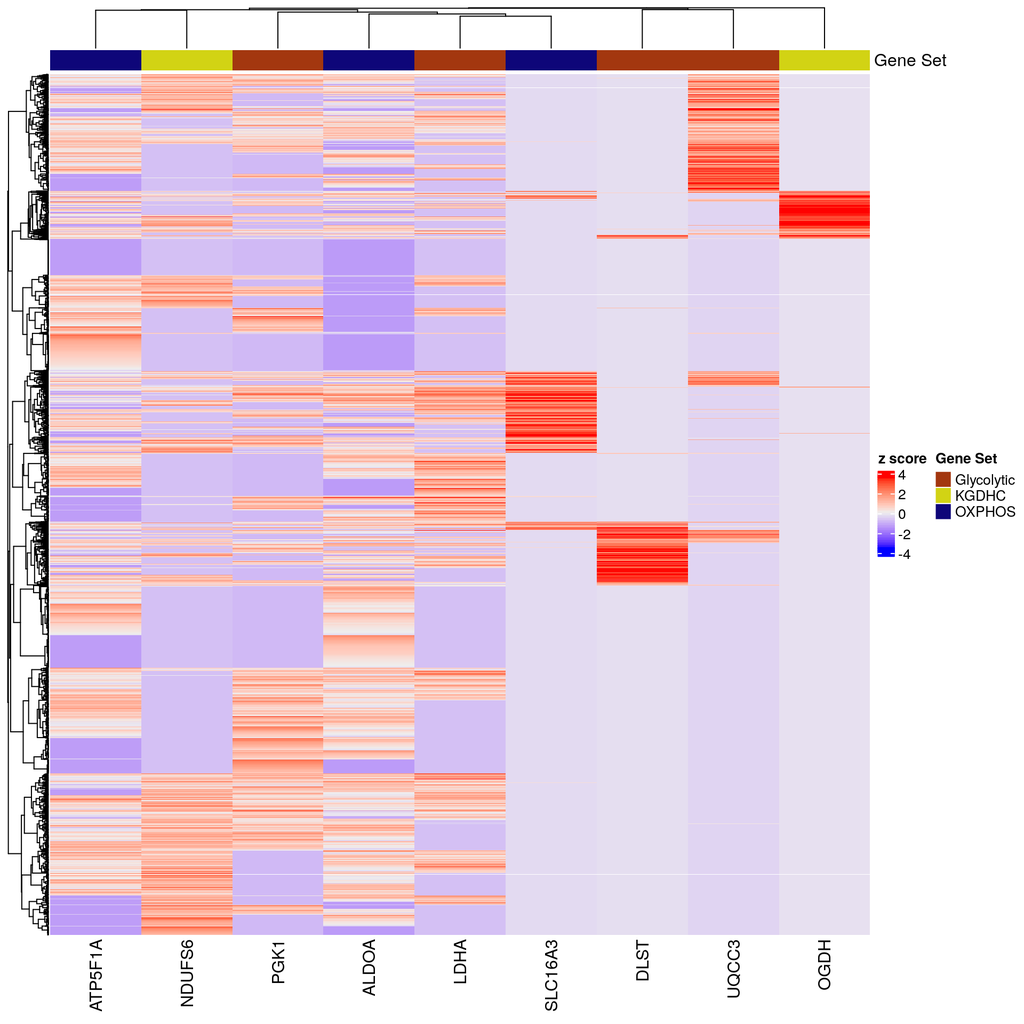

```r
# create the ComplexHeatmap
Heatmap(normalized_sce_zscores_matrix,
        # implement a correlation based distance metric
        clustering_distance_rows = "pearson",
        # calculate the average distance between each cluster before merging
        clustering_method_rows = "average",
        clustering_distance_columns = "pearson",
        clustering_method_columns = "average",
        show_row_names = FALSE,
        show_column_names = TRUE,
        top_annotation = column_annotation,
        name = "z score")
```

## 0.4 Single gene expression plots

### 0.4.1 Sina plots

The plot below displays the normalized and transformed expression for each of the provided marker genes in comparison to the mean expression of all genes present in the dataset.

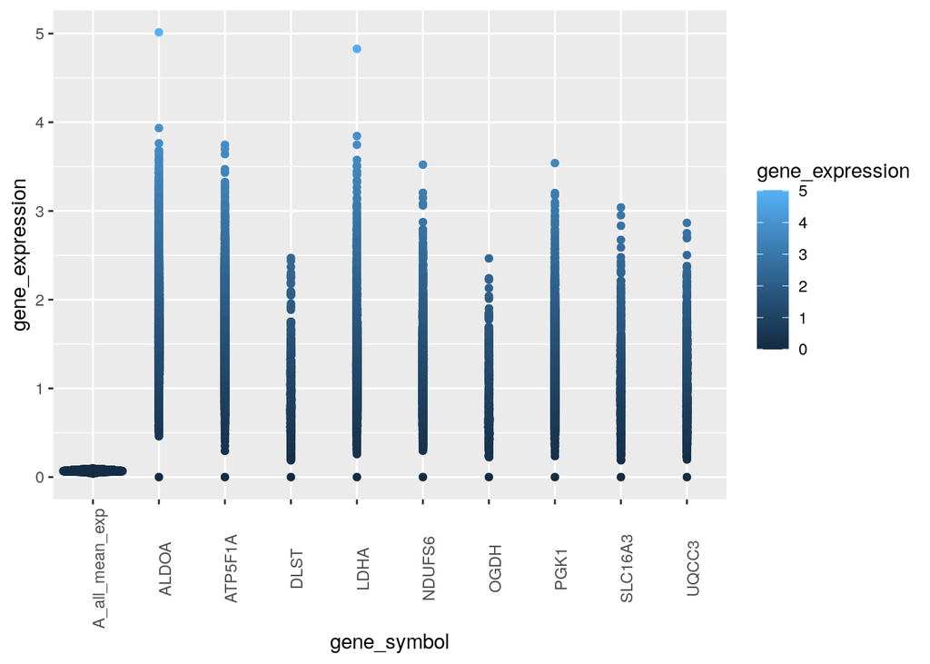

```r
# plot expression of marker genes
plot_markers_expression_sina(normalized_sce,
                             marker_genes,
                             params$ensembl_id_column,
                             params$gene_symbol_column)
```

### 0.4.2 UMAP plots

Each plot below represents the UMAP results calculated using this sample’s data. Each dot represents a cell and the color indicates the individual marker gene expression (each plot being relevant to a single marker gene).

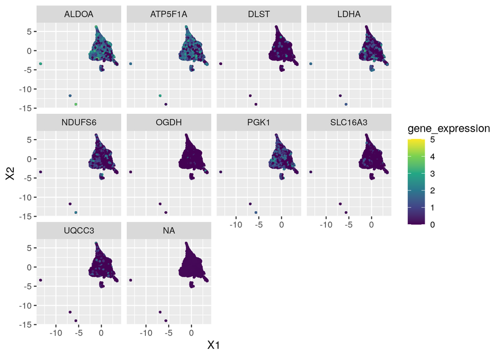

```r
plot_markers_expression_umap(normalized_sce,
                             marker_genes,
                             params$ensembl_id_column,
                             params$gene_symbol_column)
```

### 0.4.3 PCA plots

Each plot below represents the PCA results calculated using this sample’s data. Each dot represents a cell and the color indicates the individual marker gene expression (each plot being relevant to a single marker gene).

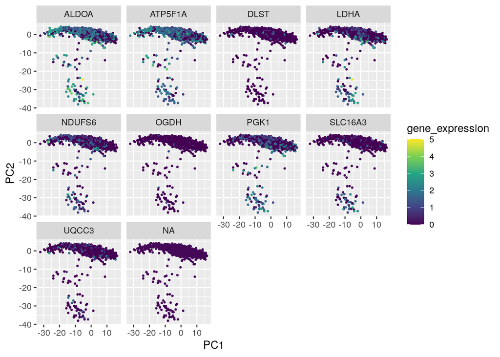

```r
plot_markers_expression_pca(normalized_sce,
                            marker_genes,
                            params$ensembl_id_column,
                            params$gene_symbol_column)
```